# Introdution to Generalized Linear Models

O Rodriguez de Rivera Ortega, PhD

University of Exeter

## Introdution

- This session provides an overview of generalized linear models (GLMs).
- We shall see that these models extend the linear modelling framework to variables that are not Normally distributed.
- GLMs are most commonly used to model binary or count data, so we will focus on models for these types of data.

## The General Linear Model

In a general linear model

$$y_{i} = \beta_{0} + \beta_{1}x_{1i} +
\beta_{2}x_{2i} + ... + \beta_{p}x_{pi}$$

the **response** $y_{i}$, $i$=1, …, n is modeled by a linear function of **explanatory** variables $x_{j}$, $j$=1, …, $p$ plus an error term.

## General and linear

Here **general** refers to the dependence on potentially more than one explanatory variable, v.s. the **simple linear model**

$$y_{i} = \beta_{0} + \beta_{1}x_{i} +
e_{i}$$

The model is *linear in the parameters*, e.g.

$$y_{i} = \beta_{0} + \beta_{1}x_{1}
+\beta_{2}x_{1}^2 + e_{i}$$
$$y_{i} =
\beta_{0} + \gamma_{1}\delta_{1}x_{i} + e^{\beta_{2}}x_{2}
+ e_{i}$$
but not e.g.

$$y_{i} = \beta_{0} +
\beta_{1}x_{1}^{\beta_{2}} + e_{i}$$
$$y_{i} = \beta_{0} + e^{\beta_{1}x_{1}}
+ e_{i}$$

## Error structure

We assume that errors $e_{i}$ are independent and identically distributed such that

$$E[e_{i}] = 0$$
and
$$var[e_{i}] = \sigma^{2}$$

Typically we assume

$$e_{i} \sim N(0, \sigma^{2})$$
as a basis for inference, e.g. t-test on parameters.

## Restrictions of Linear Models

Although a very useful framework, there are some situations where general linear models (GLM) are not appropriate

- the range of $Y$ is restricted (e.g. binary, count)
- the variance of $Y$ depends on the mean

**Generalized linear models** extend the general linear model framework to address both of these issues.

## Generalised Linear Models (GLMs)

A **generalized linear model** is made up of a **linear predictor**

$$\eta_{i} = \beta_{0} + \beta_{1}x_{1i} +
\beta_{2}x_{2i} + ... + \beta_{p}x_{pi}$$
and two functions

- a **link** function that describes how the mean, $E(Y_{i}) = \mu_{i}$, depends on the linear predictor

$$g(\mu_{i}) = \eta_{i}$$
* a **variance** function that describes how the variance, $var(Y_{i})$ depends on the mean

$$var(Y_{i}) = \phi V(\mu)$$
where de **dispersion parameter** $\phi$ is a constant.

## Normal General Linear model

For the general linear model with $e \sim N(0,\sigma^{2})$ we have the linear predictor

$$\eta_{i} = \beta_{0} + \beta_{1}x_{1i} +
\beta_{2}x_{2i} + ... + \beta_{p}x_{pi}$$
the link function
$$g(\mu_{i}) = \mu_{i}$$
and the variance function
$$V(\mu_{i}) = 1$$

## Modeling Binomial Data

Suppose

$$Y_{i} \sim Binomial(n_{i},
p_{i})$$
and we wish to model the proportions $Y_{i} / n_{i}$. Then

$$E(Y_{i}/n_{i})= p_i$$
$$var(Y_{i}/n_{i}) = \frac{1}{n_{i}} p_{i}
(1-p{i})$$

So our function is

## Transformation v.s. GLM

In some situations a response variable can be transformed to improve linearity and homogeneity of variance so that a general linear model can be applied.

This approach has some drawbacks

For example, a common remedy for the variance increasing with the mean is to apply a log transform, e.g.
$$log(y_{i}) = \beta_{0} + \beta_{1}x_{1} +
e_{1}$$

$$\Rightarrow E(logY_{i}) = \beta_{0} +
\beta_{1}x_{1}$$
This is a linear model for the mean of log$Y$ which may not always be appropriate. E.g. if $Y$ is income perhaps we are really interested in the mean income of population subgroups, in which case it would be better to model $E(Y)$ using glm:

$$log E(Y_{i}) = \beta_{0} +
\beta_{1}x_{1})$$
with $V(\mu)=\mu$. This avoids difficulties with $y = 0$

## Exponential Family

Most of the commonly used statistical distributions, e.g. Normal, Binomial and Poisson, are members of the exponential family of distributions whose identities can be writen in the form

$$f(y; \theta, \phi) = exp
\bigg\{\frac{y\theta-b(\theta)}{\phi+c(y,\theta)}\bigg\}$$
where $\phi$ is the dispersion parameter and $\theta$ is the **canonical parameter**.

It can be shown that
$$E(Y)=b'(\theta)=\mu$$
and
$$var(Y)=\phi b''(\theta)=\phi
V(\mu)$$

## Canonical Links

For a glm where the response follows and exponential distribution we have

$$g(\mu_{i})=g(b'(\theta))=\beta_{0}+\beta_{1}x_{1i}+...+\beta_{p}x_{pi}$$
The **canonical link** is defined as
$$g=(b')^{-1}$$
$$\Rightarrow
g(\mu_{1})=\theta_{i}=\beta_{0}+\beta_{1}x_{1i}+...+\beta_{p}x_{pi}$$
Canonical links lead to desirable statistical properties of the glm hence tend to be used by default. However there is no *a priori* reason why the systematic effects in the model should be additive on the scale given by this link.

## Estimation of the Model Parameters

A single algorithm can be used to estimate the parameters of an exponential family glm using maximum likelihood.

The log-likelihood for example $y_{1},...,y_{n}$
$$l=\sum_{i=1}^{n}
\frac{y_{i}-\mu_{i}}{\phi_{i}V(\mu_{i})} + c(y_{i},\phi_{i})$$
The maximum likelihood estimates are obtained by solving the score equations
$$s(\beta_{j})=\frac{\partial
l}{\partial
\beta_{j}}=\sum_{i=1}^{n}\frac{y_{i}-\mu_{i}}{\phi_{i}V(\mu_{i})}\times\frac{x_{ij}}{g'(\mu_{ij})}=0$$
for parameters $\beta_{j}$

## Standard Errors

The estimates $\hat{\beta}$ have the usual properties of maximum likelihood estimators. In particular, $\hat{\beta}$ is assymptotically

$$N(\beta,i^{-1})$$
where
$$i(\beta)=\phi^{-1}X^{T}WX$$
Standard errors for $\beta_{j}$ may therefore be calculated as the square roots of the diagonal elements of

$$\hat{cov}(\hat{\beta})=\phi(X^{T}\hat{W}X)^{-1}$$

in which $(X^{T}\hat{W}X)^{-1}$ is a by-product of the final IWLS iteration. If $\phi$ is unknown, an estimate is required.

## The `**glm**` Function

Generalized linear models can be fitted in R using the `glm` function, which is similar to the `lm` function for fitting linear models.

The arguments to a `glm` call are as follows

`glm(formula, family = gaussian, data, weights, subset,`  
`na.action, start = NULL, etastart, mustart, offset,`  
`control = glm.control(...), model = TRUE,`  
`method = ”glm.fit”, x = FALSE, y = TRUE,`  
`contrasts = NULL, ...)`

## Formula Argument

The formula is specified to `glm` as, e.g.

**y** $\sim$ x1 + x2

where **x1** and **x2** are the names of *numeric vectors (continuous variables)* factors (categorical variables)

All specified variables must be in the workspace or in the data frame passed to the **data** argument.

Other symbols that can be used in the formula include

- **a:b** for an interaction between **a** and **b**
- **a*b** which expands to **a + b + a:b**
- **.** for first order terms of all variables in data
- **-** to exclude a term or terms
- **1** to include an intercept (included by default)
- **0** to exclude an intercept

## Family argument

The **family** argument takes (the name of) a family function which specifies

- the link function
- the variance function
- various related objects used by `glm`, e.g. `linkinv`

The exponential family functions available in R are

- **binomial(link = “logit”)**
- **gaussian(link = “identity”)**
- **Gamma(link = “inverse”)**
- **inverse.gaussian(link = “1/mu2”)**
- **poisson(link = “log”)**

## Extractor Functions

The glm function returns an object of class **c(`"glm"`, `"lm"`)**

There are several `glm` or `lm` methods available for accessing/displaying components of the `glm` object, including:

- **residuals()**
- **fitted()**
- **predict()**
- **coef()**
- **deviance()**
- **formula()**
- **summary()**

## Example: Forest Inventory Murcia

First, we plot the scatterplot

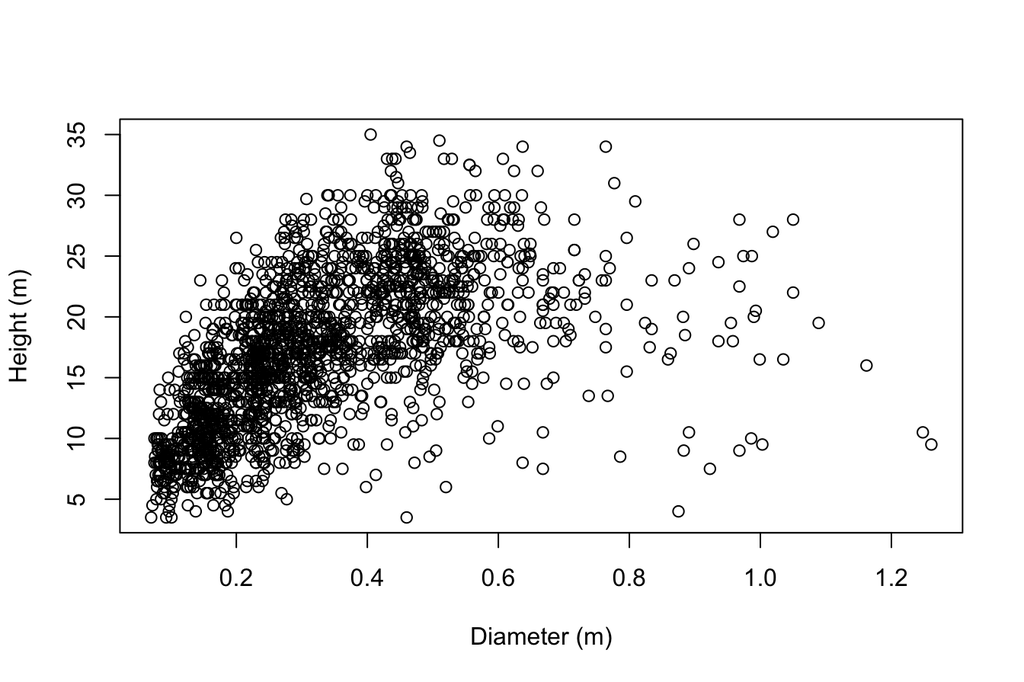

```r
# plot the distribution of species
plot(Height ~ Diameter1, data=FI_Murcia_sub  ,xlab = "Diameter (m)", ylab = "Height (m)")
```

## Summary of Fit using `lm`

We will first fit the model using `lm`, then compare to the results using `glm`.

```
##
## Call:
## lm(formula = Height ~ Diameter1, data = FI_Murcia_sub)
##
## Residuals:
##      Min       1Q   Median       3Q      Max
## -25.6852  -3.4727  -0.0211   3.3744  16.3985
##
## Coefficients:
##             Estimate Std. Error t value Pr(>|t|)
## (Intercept)  10.7553     0.2552   42.14   <2e-16 ***
## Diameter1    19.3735     0.6790   28.53   <2e-16 ***
## ---
## Signif. codes:  0 '***' 0.001 '**' 0.01 '*' 0.05 '.' 0.1 ' ' 1
##
## Residual standard error: 5.201 on 1793 degrees of freedom
## Multiple R-squared:  0.3123, Adjusted R-squared:  0.3119
## F-statistic: 814.2 on 1 and 1793 DF,  p-value: < 2.2e-16
```

## Summary of Fit using `glm`

```
##
## Call:
## glm(formula = Height ~ Diameter1, data = FI_Murcia_sub)
##
## Coefficients:
##             Estimate Std. Error t value Pr(>|t|)
## (Intercept)  10.7553     0.2552   42.14   <2e-16 ***
## Diameter1    19.3735     0.6790   28.53   <2e-16 ***
## ---
## Signif. codes:  0 '***' 0.001 '**' 0.01 '*' 0.05 '.' 0.1 ' ' 1
##
## (Dispersion parameter for gaussian family taken to be 27.04756)
##
##     Null deviance: 70519  on 1794  degrees of freedom
## Residual deviance: 48496  on 1793  degrees of freedom
## AIC: 11017
##
## Number of Fisher Scoring iterations: 2
```

Partial t-tests test the significance of each coefficient in the presence of the others. The dispersion parameter for the gaussian family is equal to the residual variance.

Different model summaries are reported for GLMs. First we have the deviance of two models:

```
Null deviance: 70519  on 1794  degrees of freedom
```

Residual deviance: 48496 on 1793 degrees of freedom

The first refers to the null model in which all of the terms are excluded, except the intercept if present. The degrees of freedom for this model are the number of data points $n$ minus 1 if an intercept is fitted.

The second two refer to the fitted model, which has $n - p$ degrees of freedom, where $p$ is the number of parameters, including any intercept.

## Deviance

The deviance of a model is defined as

$$D = 2\phi(l_{sat} -
l_{mod})$$

where $l_{mod}$ is the log-likelihood of the fitted model and $l_{sat}$ is the log-likelihood of the saturated model. In the saturated model, the number of parameters is equal to the number of observations, so $\hat{y} = y$.

For linear regression with Normal data, the deviance is equal to the residual sum of squares.

## Akiake Information Criterion (AIC)

Finally we have:

`AIC: 11017`

`Number of Fisher Scoring iterations: 2`

The AIC is a measure of fit that penalizes for the number of parameters $p$
$$AIC = -2l_{mod} + 2p$$
Smaller values indicate better fit and thus the AIC can be used to compare models (not necessarily nested).

## Residual Analysis

Several kinds of residuals can be defined for GLMs:

- *response*: $y_{i} - \mu_{i}$
- *working*: from the working response in the IWLS algorithm
- *Pearson*
  $$r_{i}^{P} =
  \frac{y_{i} - \mu_{i}} {\sqrt{V(\hat{\mu_i})}}$$
  s.t. $\sum_{i}(r_{i}^P)^2$ equals the generalized Pearson statistic.
- *deviance* r_{i}^D equals $\sum_{i}(r_{i}^D)^2$ the deviance

Deviance residuals are the default used in R, since they reflect the same criterion as used in the fitting. For example we can plot the deviance residuals against the fitted values ( on the response scale) as follows:

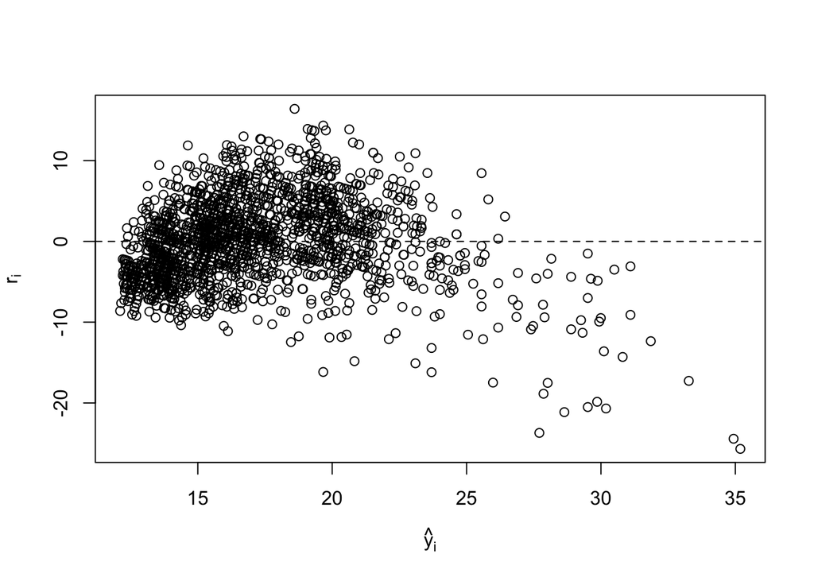

## Residual Plots

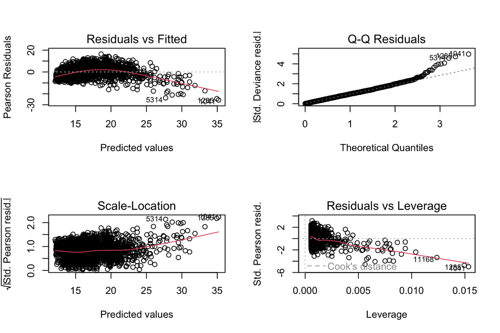